# Untitled

Willian Meira Schlichta

14 de novembro de 2018

# 1. Base de Dados

Os dados foram retirados do pacote “DAAG”, sendo dados dos EUA, entre 1997-2002, de acidentes de carro relatados pela polícia nos quais há um evento prejudicial (pessoas ou propriedade) e do qual pelo menos um veículo foi rebocado. Os dados são restritos aos ocupantes do banco da frente, incluem apenas um subconjunto das variáveis registradas e são restritos de outras maneiras também.

**1.1 Descrição dos dados**

A base original possui uma base de dados com 26.217 observações nas 15 variáveis a seguir:

1 - **dvcat**: velocidades estimadas do impacto do acidente: 1-9km/h, 10-24, 25-39, 40-54, 55+  
2 - **weight**: Pesos de observação  
3 - **dead**: Classificação se sobreviveu ao acidente: 1 = sobreviveu ou 0 = morreu  
4 - **airbag**: Se o carro possui airbag: com ou sem airbag  
5 - **seatbelt**: Uso do cinto de segurança: com ou sem cinto  
6 - **frontal**: Impacto do acidente: 0 = não frontal, 1 = impacto frontal  
7 - **sex**: Sexo: 0 = Feminino ou 1 = Masculino  
8 - **ageOFocc**: Idade dos ocupantes do veículo  
9 - **yearacc**: Ano do acidente (1997-2002)  
10 - **yearVeh**: Ano do veículo (1953-2003)  
11 - **abcat**: Se Airbags foram acionados: deploy, nodeploy, unavail  
12 - **occRole**: Posição do airbag acionado: driver, pass  
13 - **deploy**: Airbag acionados: 0: Se não possuia airbag ou não foi acionado, 1: Um ou mais airbags foram acionados  
14 - **injSeverity**: Gravidade do acidente: 0:none, 1 = Possível Lesão, 2:no incapacity, 3:incapacity, 4:killed; 5:unknown, 6:prior death  
15 - **caseid**: ID do caso.

O objetivo da análise foi modelar a probalidade de sobrevivencia dos acidentes de carro da base “nassCD” sob a influência do airbag e outros elementos.

Outro detalhe, devido ao número elevado de registros (mais de 26000 linhas), pegamos uma amostra de aproximadamente 10% do total de registros.

**1.2 Ajustando o formato dos dados**

Para um melhor entendimento dos dados, renomeamos os campos e em seguida apresentamos uma prévia da base.

```r
names(dados)<-c('veloc','sobrev','cinto','frontal','sexo','idade','ocupantes','abfunc')
```

```
##   veloc sobrev cinto frontal sexo idade ocupantes abfunc
## 1 25/39      1   Sim     Sim  Fem    40    driver    Sim
## 2 25/39      1   Sim     Sim Masc    41    driver    Nao
## 3 40/54      1   Sim     Nao Masc    35    driver    Sim
## 4 25/39      1   Sim     Sim Masc    26      pass    Sim
## 5 25/39      1   Sim     Sim  Fem    32    driver    Sim
## 6 25/39      1   Sim     Sim  Fem    41    driver    Sim
```

# 2 Análise Descritiva

**2.1 Medidas de Resumo e gráficos de frequencia**

Vamos avaliar o Summary do modelo:

```r
summary(dados)
```

```
##    veloc     sobrev   cinto      frontal      sexo          idade
##  01/09: 37   0:1180   Nao:1012   Nao:1009   Fem :1014   Min.   :16.0
##  10/24:711   1:1180   Sim:1348   Sim:1351   Masc:1346   1st Qu.:23.0
##  25/39:695                                              Median :36.0
##  40/54:459                                              Mean   :40.4
##  55+  :458                                              3rd Qu.:53.0
##                                                         Max.   :97.0
##   ocupantes    abfunc
##  driver:1821   Nao:1598
##  pass  : 539   Sim: 762
##
##
##
##
```

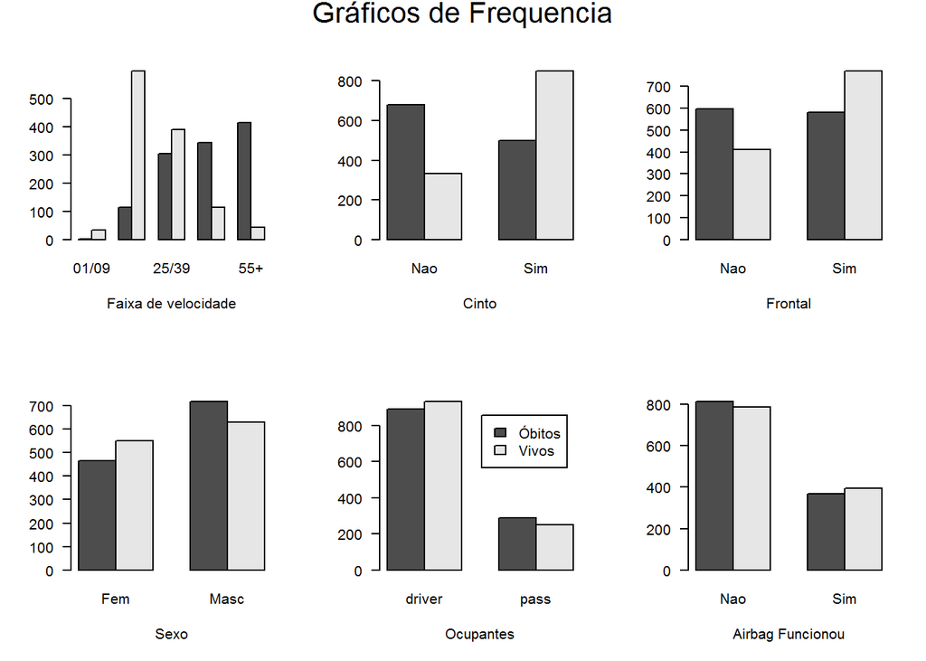

**2.2 Boxplot**

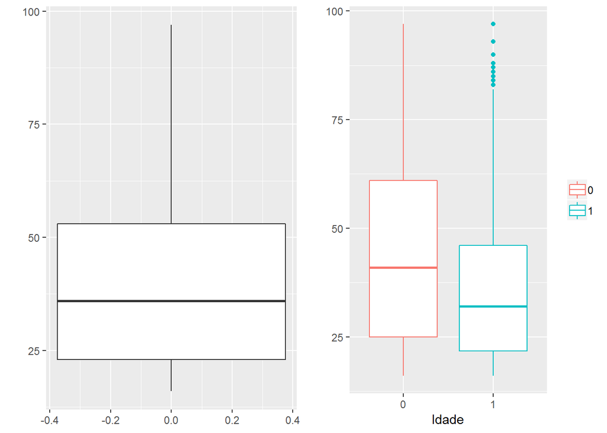

# 3. Ajuste do Modelo de Regressão

**3.1 Ligação Logito**

Vamos ajustar um Modelo Linear Generalizado Binomial com função de ligação Logito. A expressão do modelo é dada por:

$ln (\frac{\pi_i}{1-\pi_i}) = \beta_0 + \beta_1 Veloc_i + \beta_2 Cinto_i + \beta_3 Frontal_i + \beta_4 Sexo_i + \beta_5 Idade_i + \beta_6 Ocupantes_i + \beta_7 AbFunc_i$

No R, o modelo é declarado da seguinte forma:

```r
ajuste1 <- glm(sobrev ~ .,family=binomial(link='logit'),data = dados)
```

**3.2 Ligação Probito**

Vamos ajustar um Modelo Linear Generalizado Binomial com função de ligação Probito. A expressão do modelo é dada por:

$\phi^{-1} (\pi_i) = \beta_0 + \beta_1 Veloc_i + \beta_2 Cinto_i + \beta_3 Frontal_i + \beta_4 Sexo_i + \beta_5 Idade_i + \beta_6 Ocupantes_i + \beta_7 AbFunc_i$

No R, o modelo é declarado da seguinte forma:

```r
ajuste2 <- glm(sobrev ~ .,family=binomial(link = 'probit'),data = dados)
```

**3.3 Ligação Complemento log-log**

Vamos ajustar um Modelo Linear Generalizado Binomial com função de ligação Complemento Log Log. A expressão do modelo é dada por:

$ln[-ln(1-\pi_i)] = \beta_0 + \beta_1 Veloc_i + \beta_2 Cinto_i + \beta_3 Frontal_i + \beta_4 Sexo_i + \beta_5 Idade_i + \beta_6 Ocupantes_i + \beta_7 AbFunc_i$

No R, o modelo é declarado da seguinte forma:

```r
ajuste3 <- glm(sobrev ~ .,family=binomial(link='cloglog'),data = dados)
```

**3.4 Ligação Cauchy**

Vamos ajustar um Modelo Linear Generalizado Binomial com função de ligação Cauchy. A expressão do modelo é dada por:

$tan[\pi_i(\mu_i- 0,5)] = \beta_0 + \beta_1 Veloc_i + \beta_2 Cinto_i + \beta_3 Frontal_i + \beta_4 Sexo_i + \beta_5 Idade_i + \beta_6 Ocupantes_i + \beta_7 AbFunc_i$

No R, o modelo é declarado da seguinte forma:

```r
ajuste4 <- glm(sobrev ~ .,family=binomial(link='cauchit'),data = dados)
```

# 4. Escolha do Modelo

O critério de informação AIC pode também ser utilizado, porém o AIC penaliza o número de parâmetros do modelo. Como os modelos tem o mesmo número de parâmetr os, o critério aponta para a mesma direção da verossimilhança pois todos são penalizados da mesma forma.

```r
selec <- data.frame(ajuste=c('logito', 'probito', 'cloglog', 'cauchy'),
                    aic=c(AIC(ajuste1), AIC(ajuste2), AIC(ajuste3), AIC(ajuste4)),
                    logLik=c(logLik(ajuste1),logLik(ajuste2),logLik(ajuste3),logLik(ajuste4)))
selec
```

```
##    ajuste      aic     logLik
## 1  logito 2034.195 -1006.0977
## 2 probito 2041.360 -1009.6800
## 3 cloglog 2017.046  -997.5229
## 4  cauchy 2040.135 -1009.0675
```

O modelo que apresentou menor AIC e maior verossimilhança foi o modelo Binomial com função de ligação Complemento log-log

# 5. Análise do Modelo Ajustado Selecionado

**5.1 Resumo do Modelo**

```r
summary(ajuste3)
```

```
##
## Call:
## glm(formula = sobrev ~ ., family = binomial(link = "cloglog"),
##     data = dados)
##
## Deviance Residuals:
##     Min       1Q   Median       3Q      Max
## -3.2520  -0.6585  -0.0678   0.6115   2.6798
##
## Coefficients:
##                Estimate Std. Error z value Pr(>|z|)
## (Intercept)   -0.218684   0.124753  -1.753  0.07961 .
## veloc.L       -2.713324   0.199170 -13.623  < 2e-16 ***
## veloc.Q       -0.544207   0.170763  -3.187  0.00144 **
## veloc.C        0.096747   0.120240   0.805  0.42104
## veloc^4        0.035443   0.075571   0.469  0.63906
## cintoSim       0.939264   0.076001  12.359  < 2e-16 ***
## frontalSim     0.619072   0.073776   8.391  < 2e-16 ***
## sexoMasc      -0.175861   0.072152  -2.437  0.01480 *
## idade         -0.024229   0.001915 -12.651  < 2e-16 ***
## ocupantespass -0.221483   0.085244  -2.598  0.00937 **
## abfuncSim      0.004925   0.077029   0.064  0.94902
## ---
## Signif. codes:  0 '***' 0.001 '**' 0.01 '*' 0.05 '.' 0.1 ' ' 1
##
## (Dispersion parameter for binomial family taken to be 1)
##
##     Null deviance: 3271.7  on 2359  degrees of freedom
## Residual deviance: 1995.0  on 2349  degrees of freedom
## AIC: 2017
##
## Number of Fisher Scoring iterations: 6
```

**5.2 Reajuste do Modelo**

Como próximo passo, iremos inserir as covariáveis uma a uma no modelo, para verificar sua significância na presença das outras. Para isso usaremos o algoritmo stepwise. Sendo assim, o novo modelo fica da seguinte forma:

```r
ajuste3.1 <- step(ajuste3, direction = "both")
```

Comparando o modelo restrito com o modelo completo temos

```
##   ajuste      aic    logLik      Dev
## 1    aj3 2017.046 -997.5229 1995.046
## 2  aj3.1 2015.050 -997.5250 1995.050
```

Verificamos que há pouca diferenças entre os modelos. Para confirmar testaremos as hipóteses: $H_0$: modelos não diferem X $H_1$: modelos diferem

```r
anova(ajuste3, ajuste3.1, test = 'Chisq')
```

```
## Analysis of Deviance Table
##
## Model 1: sobrev ~ veloc + cinto + frontal + sexo + idade + ocupantes +
##     abfunc
## Model 2: sobrev ~ veloc + cinto + frontal + sexo + idade + ocupantes
##   Resid. Df Resid. Dev Df   Deviance Pr(>Chi)
## 1      2349       1995
## 2      2350       1995 -1 -0.0042046   0.9483
```

```r
summary(ajuste3)
```

```
##
## Call:
## glm(formula = sobrev ~ ., family = binomial(link = "cloglog"),
##     data = dados)
##
## Deviance Residuals:
##     Min       1Q   Median       3Q      Max
## -3.2520  -0.6585  -0.0678   0.6115   2.6798
##
## Coefficients:
##                Estimate Std. Error z value Pr(>|z|)
## (Intercept)   -0.218684   0.124753  -1.753  0.07961 .
## veloc.L       -2.713324   0.199170 -13.623  < 2e-16 ***
## veloc.Q       -0.544207   0.170763  -3.187  0.00144 **
## veloc.C        0.096747   0.120240   0.805  0.42104
## veloc^4        0.035443   0.075571   0.469  0.63906
## cintoSim       0.939264   0.076001  12.359  < 2e-16 ***
## frontalSim     0.619072   0.073776   8.391  < 2e-16 ***
## sexoMasc      -0.175861   0.072152  -2.437  0.01480 *
## idade         -0.024229   0.001915 -12.651  < 2e-16 ***
## ocupantespass -0.221483   0.085244  -2.598  0.00937 **
## abfuncSim      0.004925   0.077029   0.064  0.94902
## ---
## Signif. codes:  0 '***' 0.001 '**' 0.01 '*' 0.05 '.' 0.1 ' ' 1
##
## (Dispersion parameter for binomial family taken to be 1)
##
##     Null deviance: 3271.7  on 2359  degrees of freedom
## Residual deviance: 1995.0  on 2349  degrees of freedom
## AIC: 2017
##
## Number of Fisher Scoring iterations: 6
```

```
##
## Call:
## glm(formula = sobrev ~ veloc + cinto + frontal + sexo + idade +
##     ocupantes, family = binomial(link = "cloglog"), data = dados)
##
## Deviance Residuals:
##     Min       1Q   Median       3Q      Max
## -3.2473  -0.6575  -0.0677   0.6130   2.6813
##
## Coefficients:
##                Estimate Std. Error z value Pr(>|z|)
## (Intercept)   -0.217251   0.123304  -1.762  0.07808 .
## veloc.L       -2.713418   0.199210 -13.621  < 2e-16 ***
## veloc.Q       -0.544245   0.170792  -3.187  0.00144 **
## veloc.C        0.096582   0.120230   0.803  0.42179
## veloc^4        0.035574   0.075558   0.471  0.63778
## cintoSim       0.939304   0.075979  12.363  < 2e-16 ***
## frontalSim     0.619851   0.072365   8.566  < 2e-16 ***
## sexoMasc      -0.175929   0.072097  -2.440  0.01468 *
## idade         -0.024234   0.001915 -12.653  < 2e-16 ***
## ocupantespass -0.221823   0.084982  -2.610  0.00905 **
## ---
## Signif. codes:  0 '***' 0.001 '**' 0.01 '*' 0.05 '.' 0.1 ' ' 1
##
## (Dispersion parameter for binomial family taken to be 1)
##
##     Null deviance: 3271.7  on 2359  degrees of freedom
## Residual deviance: 1995.1  on 2350  degrees of freedom
## AIC: 2015.1
##
## Number of Fisher Scoring iterations: 6
```